# Uncovering TV Show Popularity: A Data-Driven Analysis with TMDB

**Team Members:**

### Rishi Paladugu

- **A: Project Idea**
  - Developed the core project idea and identified key questions for analysis using the TMDB TV dataset.
- **D: ML Algorithm Design/Development**
  - Designed machine learning models to uncover patterns and predict insights from the data.

### Aditya Dabeer

- **C: Data Exploration and Summary Statistics**
  - Conducted exploratory data analysis to identify trends, patterns, and statistical insights in the dataset.
- **D: ML Algorithm Design/Development**
  - Collaborated on creating machine learning models to answer the key questions effectively.
- **F: Visualization, Result Analysis, and Conclusion**
  - Produced visualizations to present results clearly and wrote the conclusions summarizing findings.

### DaMarr Savoy

- **B: Dataset Curation and Preprocessing**
  - Collected and cleaned the dataset, ensuring it was ready for analysis.
- **E: ML Algorithm Training and Test Data Analysis**
  - Trained machine learning models and evaluated their performance on training and test datasets.
- **G: Final Tutorial Report Creation**
  - Compiled the report into a cohesive and structured format for presentation.
- **H: Additional Contributions**
  - Managed project coordination and ensured adherence to deadlines and requirements.

## Introduction

Television data offers valuable insights into viewership patterns, content success, and production trends, making it a critical resource for understanding what drives audience interest. This project leverages the TMDB TV dataset, a comprehensive repository of information on television shows, including attributes such as the number of episodes, seasons, vote counts, average ratings, genres, and more. By analyzing this dataset, we aim to uncover the factors that contribute to a show's success and popularity.

Specifically, this analysis is structured to address the following key questions:

1. **What are the main features influencing a show's popularity?**
2. **Which features are most significant in determining whether a TV show is popular or not?**
3. **Can we accurately classify whether a TV show is popular based on its features?**

By addressing these questions, this project aims to provide actionable insights for media companies and streaming platforms. The findings can help these organizations optimize their content strategies, allocate resources effectively, and improve audience engagement by delivering content that aligns with viewer preferences.

[figure not shown]

## Data Curation

**Dataset Source:**  
The dataset was obtained from **The Movie Database (TMDB)**, a comprehensive platform offering detailed information about TV shows, movies, and associated metadata.

**Dataset Description:**  
The dataset includes attributes such as the number of seasons, episodes, ratings, popularity scores, and more. Its size and variety make it ideal for machine learning applications and exploratory data analysis.

### Preprocessing Steps

[figure not shown]

```python
#imports
import pandas as pd
import matplotlib.pyplot as plt
import seaborn as sns
from scipy import stats
from sklearn.model_selection import train_test_split
from sklearn.preprocessing import StandardScaler
from sklearn.ensemble import RandomForestClassifier
from sklearn.metrics import accuracy_score, classification_report, confusion_matrix
from sklearn.metrics import precision_recall_curve

# Load the dataset
df = pd.read_csv('TMDB_tv_dataset_v3.csv')
```

#### Lets do some basic cleaning and exploration

```python
## Converting columns to integers
#'id', 'number_of_seasons', 'number_of_episodes', 'vote_count' to integers
df['id'] = df['id'].astype(int)
df['number_of_seasons'] = df['number_of_seasons'].fillna(0).astype(int)
df['number_of_episodes'] = df['number_of_episodes'].fillna(0).astype(int)
df['vote_count'] = df['vote_count'].fillna(0).astype(int)
```

```python
df.describe()
```

|  | id | number_of_seasons | number_of_episodes | vote_count | vote_average | popularity | episode_run_time |
| --- | --- | --- | --- | --- | --- | --- | --- |
| count | 168639.000000 | 168639.000000 | 168639.000000 | 168639.000000 | 168639.000000 | 168639.000000 | 168639.000000 |
| mean | 111307.074704 | 1.548497 | 24.465082 | 13.305054 | 2.333843 | 5.882644 | 22.603348 |
| std | 76451.662352 | 2.942872 | 134.799622 | 190.809059 | 3.454334 | 42.023216 | 47.950427 |
| min | 1.000000 | 0.000000 | 0.000000 | 0.000000 | 0.000000 | 0.000000 | 0.000000 |
| 25% | 45936.500000 | 1.000000 | 1.000000 | 0.000000 | 0.000000 | 0.600000 | 0.000000 |
| 50% | 97734.000000 | 1.000000 | 6.000000 | 0.000000 | 0.000000 | 0.857000 | 0.000000 |
| 75% | 196923.500000 | 1.000000 | 20.000000 | 1.000000 | 6.000000 | 2.431500 | 42.000000 |
| max | 251213.000000 | 240.000000 | 20839.000000 | 21857.000000 | 10.000000 | 3707.008000 | 6032.000000 |

```python
df.info()
```

```
<class 'pandas.core.frame.DataFrame'>
RangeIndex: 168639 entries, 0 to 168638
Data columns (total 29 columns):
 #   Column                Non-Null Count   Dtype
---  ------                --------------   -----
 0   id                    168639 non-null  int64
 1   name                  168634 non-null  object
 2   number_of_seasons     168639 non-null  int64
 3   number_of_episodes    168639 non-null  int64
 4   original_language     168639 non-null  object
 5   vote_count            168639 non-null  int64
 6   vote_average          168639 non-null  float64
 7   overview              93333 non-null   object
 8   adult                 168639 non-null  bool
 9   backdrop_path         77780 non-null   object
```

[output cut: 21 more lines]

```python
# Fill missing values in numerical columns with 0, retain all columns
df['number_of_seasons'] = df['number_of_seasons'].fillna(0).astype(int)
df['number_of_episodes'] = df['number_of_episodes'].fillna(0).astype(int)
df['vote_count'] = df['vote_count'].fillna(0).astype(int)
df['vote_average'] = df['vote_average'].fillna(0).astype(float)
df['popularity'] = df['popularity'].fillna(0).astype(float)

# Check for missing values in the dataset
missing_values = df.isnull().sum()
print("Missing values in each column:\n", missing_values)
```

```
Missing values in each column:
 id                           0
name                         5
number_of_seasons            0
number_of_episodes           0
original_language            0
vote_count                   0
vote_average                 0
overview                 75306
adult                        0
backdrop_path            90859
first_air_date           31736
last_air_date            29904
homepage                117641
in_production                0
original_name                5
popularity                   0
poster_path              59902
type                         0
status                       0
tagline                 163309
genres                   68926
created_by              132143
languages                58589
networks                 71050
origin_country           31030
spoken_languages         59359
production_companies    109297
production_countries     91128
episode_run_time             0
dtype: int64
```

```python
# Drop columns with too many missing values
df_cleaned = df.drop(columns=['tagline', 'backdrop_path', 'homepage', 'created_by', 'production_companies', 'production_countries'])

# Drop rows where 'name' is missing (important column)
df_cleaned = df_cleaned.dropna(subset=['name'])
```

```python
df_cleaned = df_cleaned[(df_cleaned['vote_count'] > 100) &
                        (df_cleaned['vote_average'] > 0) &
                        (df_cleaned['number_of_seasons'] > 0) &
                        (df_cleaned['number_of_episodes'] > 0) &
                        (df_cleaned['popularity'] > 0)]
```

```python
df_cleaned['vote_count']
```

```
0       21857
1       17836
2       16161
3       15432
4       13870
        ...
3006      101
3007      101
3008      101
3009      101
3010      101
Name: vote_count, Length: 3008, dtype: int64
```

```python
df_cleaned.describe()
```

|  | id | number_of_seasons | number_of_episodes | vote_count | vote_average | popularity | episode_run_time |
| --- | --- | --- | --- | --- | --- | --- | --- |
| count | 3008.000000 | 3008.000000 | 3008.000000 | 3008.000000 | 3008.000000 | 3008.000000 | 3008.000000 |
| mean | 60096.587434 | 3.362367 | 91.993684 | 618.140625 | 7.644337 | 74.727560 | 37.183511 |
| std | 44321.797116 | 4.409720 | 489.414590 | 1290.378784 | 0.625577 | 166.171084 | 24.011101 |
| min | 5.000000 | 1.000000 | 1.000000 | 101.000000 | 0.700000 | 1.779000 | 0.000000 |
| 25% | 16110.750000 | 1.000000 | 12.000000 | 148.000000 | 7.281000 | 16.058750 | 24.000000 |
| 50% | 63399.500000 | 2.000000 | 30.000000 | 251.000000 | 7.700000 | 27.910000 | 40.000000 |
| 75% | 89064.250000 | 4.000000 | 85.000000 | 568.000000 | 8.100000 | 66.838000 | 48.000000 |
| max | 232125.000000 | 72.000000 | 20839.000000 | 21857.000000 | 8.890000 | 3707.008000 | 519.000000 |

##### Method 1: Plot vote average distribution

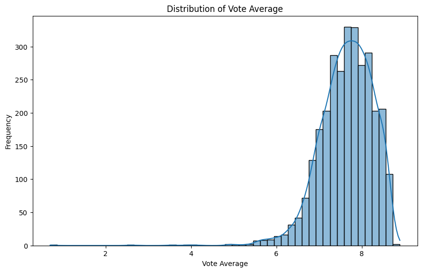

```python
plt.figure(figsize=(10, 6))
sns.histplot(df_cleaned['vote_average'], bins=50, kde=True)
plt.title('Distribution of Vote Average')
plt.xlabel('Vote Average')
plt.ylabel('Frequency')
plt.show()
```

[figure not shown]

# Methods for Data Exploration

##### Method 2: Plot histogram of vote count

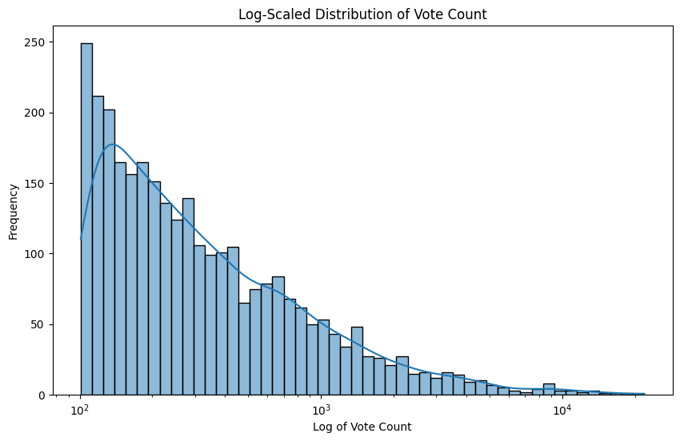

```python
plt.figure(figsize=(10, 6))
sns.histplot(df_cleaned['vote_count'], bins=50, kde=True, log_scale=(True, False))
plt.title('Log-Scaled Distribution of Vote Count')
plt.xlabel('Log of Vote Count')
plt.ylabel('Frequency')
plt.show()
```

The histogram above illustrates a distribution on a logarithmic scale. The majority of shows receive very few votes. This is indicated by the peak at the lower end of the scale. The log scale is used here to better visualize the distribution, meaning that while a few shows accumulate massive numbers of votes, most receive far fewer.

##### Method 3: Correlation between vote count and vote average

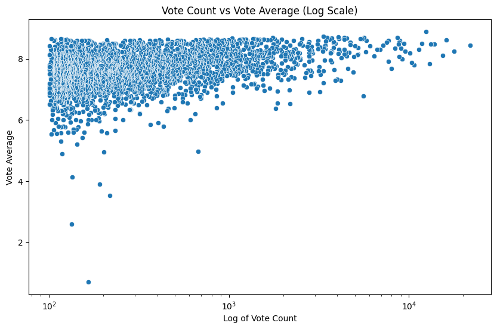

```python
plt.figure(figsize=(10, 6))
sns.scatterplot(x='vote_count', y='vote_average', data=df_cleaned)
plt.xscale('log')  # Apply log scale to the x-axis
plt.title('Vote Count vs Vote Average (Log Scale)')
plt.xlabel('Log of Vote Count')
plt.ylabel('Vote Average')
plt.show()
```

##### Heat Map for numerical columns

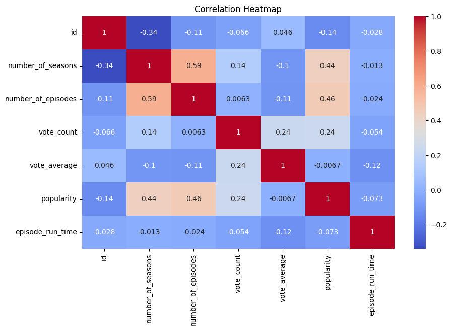

```python
numeric_cols = df_cleaned.select_dtypes(include=['float64', 'int64'])
plt.figure(figsize=(10, 6))
sns.heatmap(numeric_cols.corr(), annot=True, cmap='coolwarm')
plt.title('Correlation Heatmap')
plt.show()
```

The heatmap of the correlation matrix among numerical variables reveals the strength of relationships between different features. According to the heatmap, there is a moderate positive correlation between the number of seasons and the number of episodes, while vote count and vote average show a weak correlation. As shown on the heatmap, darker hues represent stronger correlations.

##### Hypothesis testing (T-test): Does the average rating (vote_average) differ between TV shows with more than 3 seasons and those with 3 or fewer seasons.

```python
group1 = df_cleaned[df_cleaned['number_of_seasons'] > 3]['vote_average']
group2 = df_cleaned[df_cleaned['number_of_seasons'] <= 3]['vote_average']

t_stat, p_value = stats.ttest_ind(group1.dropna(), group2.dropna())
print(f"Two-sample T-test results: T-statistic = {t_stat}, P-value = {p_value}")
if p_value < 0.05:
    print("The average rating is significantly different between the two groups (reject the null hypothesis).")
else:
    print("There is no significant difference in average ratings between the two groups (fail to reject the null hypothesis).")
```

```
Two-sample T-test results: T-statistic = 0.2581069845557183, P-value = 0.7963420104045225
There is no significant difference in average ratings between the two groups (fail to reject the null hypothesis).
```

The T-test comparing the average ratings of shows with more than 3 seasons versus those with 3 or fewer seasons reveals no significant difference between the two groups. This is shown by the p-value, which is 0.796. Since the p-value is greater than 0.05, the null hypothesis fails to be rejected. This suggests that the number of seasons in a show does not strongly influence its average viewer rating.

```
Accuracy: 0.7940199335548173

Classification Report:

              precision    recall  f1-score   support

           0       0.78      0.81      0.79       294
           1       0.81      0.78      0.79       308

    accuracy                           0.79       602
   macro avg       0.79      0.79      0.79       602
weighted avg       0.79      0.79      0.79       602
```

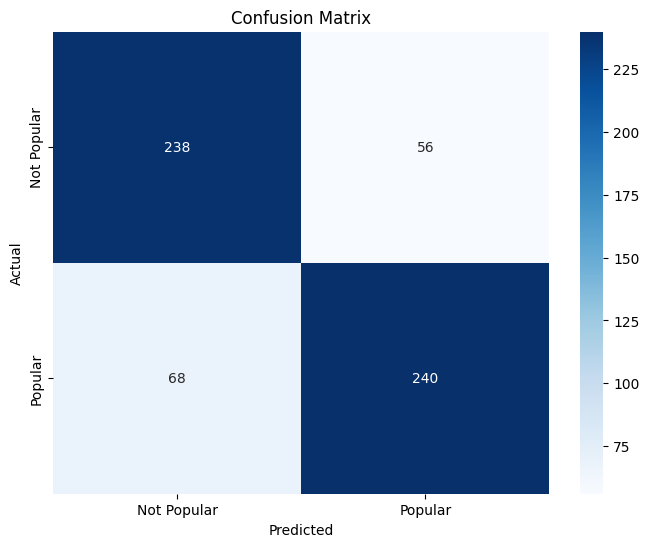

```python
median_popularity = df_cleaned['popularity'].median()
df_cleaned['is_popular'] = (df_cleaned['popularity'] > median_popularity).astype(int)

features = ['number_of_seasons', 'number_of_episodes', 'vote_count', 'vote_average', 'episode_run_time']
target = 'is_popular'

X = df_cleaned[features]
y = df_cleaned[target]


scaler = StandardScaler()
X_scaled = scaler.fit_transform(X)


X_train, X_test, y_train, y_test = train_test_split(X_scaled, y, test_size=0.2, random_state=42)

rf_clf = RandomForestClassifier(random_state=42, n_estimators=100, max_depth=None)
rf_clf.fit(X_train, y_train)

y_pred_proba = rf_clf.predict_proba(X_test)[:, 1]
y_pred_clf = rf_clf.predict(X_test)
accuracy = accuracy_score(y_test, y_pred_clf)
print(f"\nAccuracy: {accuracy}")

# Classification Report
print("\nClassification Report:\n")
print(classification_report(y_test, y_pred_clf))
conf_matrix = confusion_matrix(y_test, y_pred_clf)
plt.figure(figsize=(8, 6))
sns.heatmap(conf_matrix, annot=True, fmt='d', cmap='Blues',
            xticklabels=['Not Popular', 'Popular'],
            yticklabels=['Not Popular', 'Popular'])
plt.title("Confusion Matrix")
plt.xlabel("Predicted")
plt.ylabel("Actual")
plt.show()
```

The Confusion Matrix gives us a clear picture of how well the model is doing at predicting whether a TV show is "Popular" or "Not Popular." It shows that the model correctly identified 240 popular shows and 238 not popular ones, which is great. However, it also made some mistakes: 56 shows were wrongly classified as popular, and 68 truly popular shows were missed. These numbers matter because they help us understand how the model performs overall. For example, missing popular shows (false negatives) could mean missed opportunities to promote content that could really resonate with viewers, while wrongly labeling not popular shows as popular (false positives) could lead to wasted marketing resources.

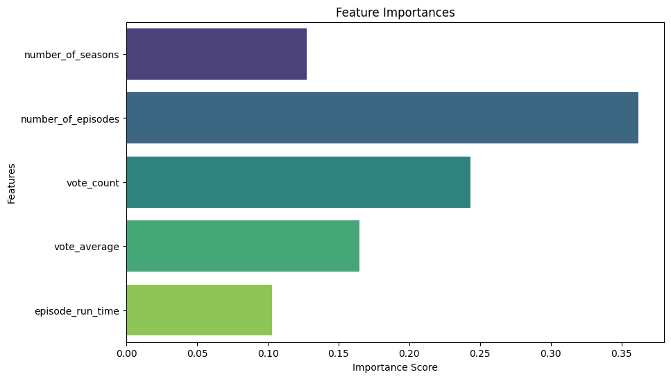

```python
# Get feature importances
importances = rf_clf.feature_importances_
feature_names = features

# Plot feature importances
plt.figure(figsize=(10, 6))
sns.barplot(x=importances, y=feature_names, palette="viridis")
plt.title("Feature Importances")
plt.xlabel("Importance Score")
plt.ylabel("Features")
plt.show()
```

This bar chart highlights the most important features influencing the popularity of a TV show, based on scores derived from the machine learning model. These scores show how much each feature contributes to the model's predictions, giving us a clear sense of what drives popularity. The number of episodes stands out as the most significant factor, suggesting that longer-running shows tend to capture more attention. Audience engagement also plays a big role, with vote count and vote average ranking highly, emphasizing the impact of viewer feedback. While features like the number of seasons and episode runtime also contribute, their influence is notably smaller. This visualization ties directly to the question "What are the main features influencing a show's popularity?" by providing a clear breakdown of which aspects matter most when predicting a show's success.

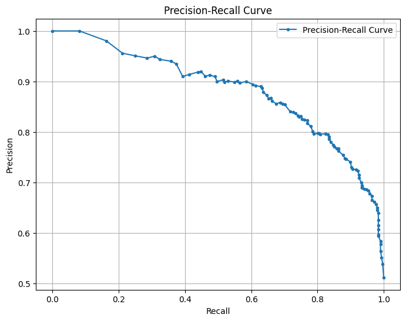

```python
# Calculate precision and recall
precision, recall, thresholds = precision_recall_curve(y_test, y_pred_proba)

# Plot the Precision-Recall curve
plt.figure(figsize=(8, 6))
plt.plot(recall, precision, marker='.', label='Precision-Recall Curve')
plt.title("Precision-Recall Curve")
plt.xlabel("Recall")
plt.ylabel("Precision")
plt.grid()
plt.legend()
plt.show()
```

The precision-recall curve provides valuable insight into how well the model distinguishes between popular and non-popular TV shows. It illustrates the balance between precision—how many of the predicted popular shows are actually popular—and recall—how many of the truly popular shows the model correctly identifies. At lower recall levels, the model achieves high precision, meaning it’s effective at identifying popular shows with very few false positives. However, as recall increases, precision decreases, which is a common trade-off in classification tasks. This curve directly relates to the question "Can we accurately classify whether a TV show is popular based on its features?" by showing that the model strikes a good balance between precision and recall, demonstrating its ability to make reliable predictions.

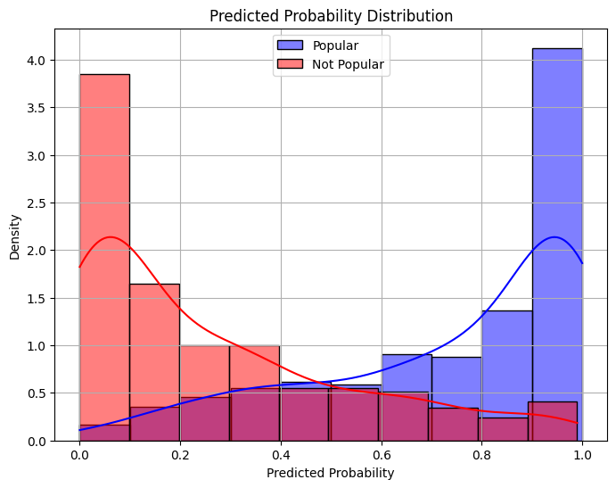

```python
# Plot predicted probabilities for both classes
plt.figure(figsize=(8, 6))
sns.histplot(y_pred_proba[y_test == 1], color="blue", label="Popular", kde=True, stat="density")
sns.histplot(y_pred_proba[y_test == 0], color="red", label="Not Popular", kde=True, stat="density")
plt.title("Predicted Probability Distribution")
plt.xlabel("Predicted Probability")
plt.ylabel("Density")
plt.legend()
plt.grid()
plt.show()
```

# Conclusion

This project helped us better understand what makes a TV show popular and how different factors contribute to its success. By analyzing the TMDB TV dataset, we identified which features matter most and used machine learning to classify shows as "popular" or "not popular." Through tools like feature importance charts, precision-recall curves, and confusion matrices, we turned raw data into meaningful insights that connect directly to real-world decisions.

One of the most interesting takeaways was how much the number of episodes influences a show’s popularity. Longer-running shows clearly tend to attract more viewers, which could guide media companies to invest in content with the potential for multiple seasons. On the other hand, features like vote counts and ratings highlight the importance of audience engagement. When viewers actively participate—whether by leaving ratings, writing reviews, or casting votes—they help boost a show’s visibility and overall appeal.

We also learned that even less obvious features, like the number of seasons or episode runtime, can play a role when combined with other factors. The machine learning model showed how these variables work together to paint a fuller picture of what drives popularity. The precision-recall curve and confusion matrix confirmed that the model was effective at distinguishing popular shows from those that didn’t quite hit the mark.

For streaming platforms and media companies, these insights are game-changers. They offer a data-driven way to predict which shows will resonate with audiences and help refine decisions about what to produce and how to engage viewers. By focusing on shows with higher episode counts and encouraging audience interaction, companies can boost their chances of creating successful content.

[figure not shown]